# Report

Chisom Ezenwa Soremekun

7/6/2021

## **Background**

This is an assessed exercise that will contribute to coursework for this module. It is aimed at providing an experience with all that has been covered throughout the semester. The tasks are based on two Bioconductor packages; phyloseq and DEseq2. Endeavor to look at the documentation and the links indicated below may be useful. The data files are located in the shared google drive folder.

## **Data sources and description**

The data used in this exercise is derived and was generated by Kolistic et al in their study “The dynamics of the human infant gut microbiome in development and progression toward Type 1 Diabetes”. See full publication at https://doi.org/10.1016/j.chom.2015.01.001. Briefly, this was a prospective analysis of developing gut microbiome in infants en route to type 1 diabetes. Infants from Finland and Estonia were recruited at birth based on predisposition to autoimmunity determined by human leukocyte antigen (HLA) genotyping. The cohort consists of 33 infants, 11 of which seroconverted to serum autoantibody positivity and of those, four developed T1D within the three-year time-frame of this study.

## **Tasks**

1. Import the data described above into R, provide descriptive summaries of the subject data (using appropriate graphics and statistical summary measures) given in the diabimmune_16s_t1d_metadata.csv file. In addition, use appropriate test(s) to check for association/independency between disease status and other variables (delivery mode, gender and age). Note that age is given in days.
2. Using phyloseq, create a phyloseq object. This will comprise the OTU abundance, taxonomy (provided in the .txt file) and sample data (provided in the .csv file).
3. Generate Alpha diversity plots and ordination plots. Examine any observed patterns by delivery mode, gender and disease status.
4. Perform differential abundance using DEseq2

### Useful links

```
●   Importing data: https://joey711.github.io/phyloseq/import-data.html
●   Ordination: https://joey711.github.io/phyloseq/plot_ordination-examples.html
●   Alpha diversity: https://joey711.github.io/phyloseq/plot_richness-examples.html
●   Differential abundance: http://joey711.github.io/phyloseq-extensions/DESeq2.html
```

## **Question 1**

### Import the data described above into R, provide descriptive summaries of the subject data (using appropriate graphics and statistical summary measures) given in the diabimmune_16s_t1d_metadata.csv file. In addition, use appropriate test(s) to check for association/independency between disease status and other variables (delivery mode, gender and age). Note that age is given in days.

### **Step 1: Import the dataset**

##### a. This helps R to read the dataset for further analysis.

```r
dataset <- read.csv("diabimmune_16s_t1d_metadata.csv")
#View(dataset)
```

#### b. Load the libraries needed for this project.

```r
library(ggplot2)
#install.packages("BiocManager")
#BiocManager::install("phyloseq")
#packageVersion("phyloseq")
#BiocManager::install("DESeq2")
library(phyloseq)
library(DESeq2)
library(tibble)
```

### **Step 2: Provide descriptive summaries of the subject data**

#### a. Retrive the summary of the datasetwhich displays several statistic summaries of the data frame.

```r
summary(dataset)
```

```
##  ï..Sample_ID        Subject_ID        Case_Control          Gender
##  Length:777         Length:777         Length:777         Length:777
##  Class :character   Class :character   Class :character   Class :character
##  Mode  :character   Mode  :character   Mode  :character   Mode  :character
##
##
##
##  Delivery_Route     Age_at_Collection
##  Length:777         Min.   :   6.0
##  Class :character   1st Qu.: 229.0
##  Mode  :character   Median : 452.0
##                     Mean   : 482.9
##                     3rd Qu.: 702.0
##                     Max.   :1233.0
```

#### ai. Check the first 6 lines of the dataset and a glimpse of the headers contained in the dataset.

```r
head(dataset)
```

```
##   ï..Sample_ID Subject_ID Case_Control Gender Delivery_Route Age_at_Collection
## 1       G36449    E001463      control   male        vaginal                62
## 2       G36034    E001463      control   male        vaginal                82
## 3       G36993    E001463      control   male        vaginal               124
## 4       G35523    E001463      control   male        vaginal               153
## 5       G36450    E001463      control   male        vaginal               187
## 6       G36028    E001463      control   male        vaginal               213
```

#### aii. Check the last 6 lines of the dataset and a glimpse of the total number of entries.

```r
tail(dataset)
```

```
##     ï..Sample_ID Subject_ID Case_Control Gender Delivery_Route
## 772       G36938    T026177      control female        vaginal
## 773       G36936    T026177      control female        vaginal
## 774       G36937    T026177      control female        vaginal
## 775       G35535    T026177      control female        vaginal
## 776       G35536    T026177      control female        vaginal
## 777       G35537    T026177      control female        vaginal
##     Age_at_Collection
## 772               570
## 773               592
## 774               646
## 775               677
## 776               703
## 777               729
```

#### b. Retrieve the number of rows and colums of the dataset.

```r
dim(dataset)
```

```
## [1] 777   6
```

#### c. Check the class of the dataset.

```r
class(dataset)
```

```
## [1] "data.frame"
```

#### d. Ascertain the number of cases and control.

```r
table(dataset$Case_Control)
```

```
##
##    case control
##     260     517
```

#### e. Ascertain the number of female and male in the dataset.

```r
table(dataset$Gender)
```

```
##
## female   male
##    412    365
```

#### f. Check the number of delivery routes.

```r
table(dataset$Delivery_Route)
```

```
##
## cesarian  vaginal
##       66      711
```

#### g. Plot a barchat of the Cases and Control against Gender.

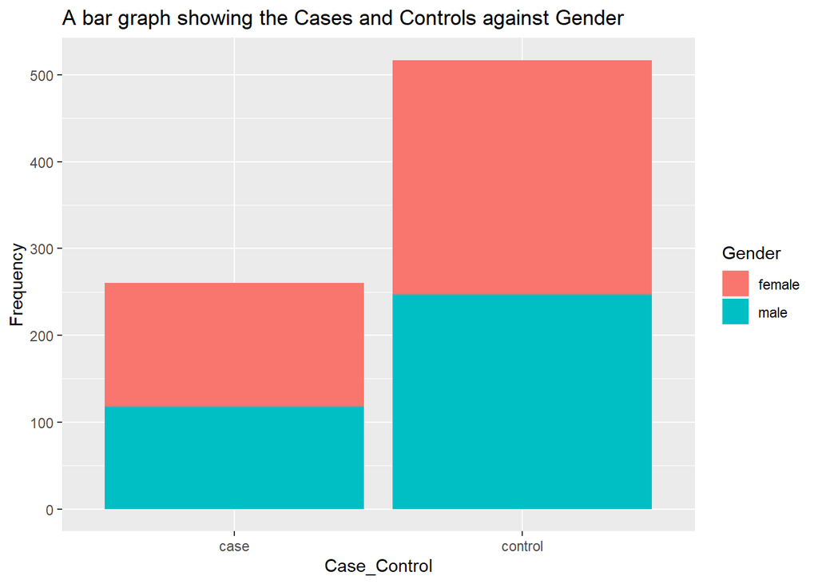

```r
qplot(dataset$Case_Control, fill = dataset$Gender) + geom_bar() + labs(title = "A bar graph showing the Cases and Controls against Gender", x = "Case_Control", y= "Frequency", fill = "Gender")
```

#### h. Plot a barchat of the Cases and Control against Delivery Route.

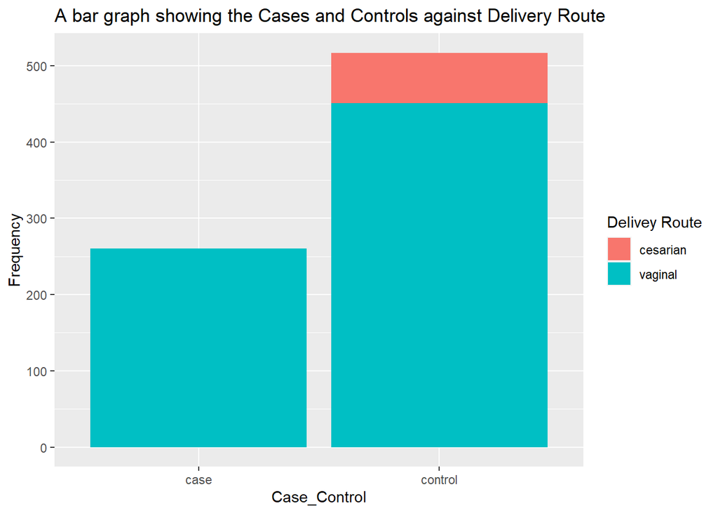

```r
qplot(dataset$Case_Control, fill = dataset$Delivery_Route) + geom_bar() + labs(title = "A bar graph showing the Cases and Controls against Delivery Route", x = "Case_Control", y= "Frequency", fill = "Delivey Route")
```

#### i. Plot a barchat showing the age distribution of the Ages of the participants.

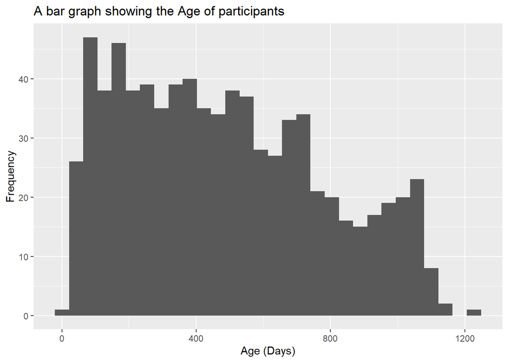

```r
qplot(dataset$Age_at_Collection) + geom_bar() + labs(title = "A bar graph showing the Age of participants", x = "Age (Days)", y= "Frequency")
```

### **Step 3: Check for association/independency between disease status and the variables.**

#### a. Association/independency between disease status and delivery mode.

#### ai. Create a contigency table

```r
ctDelivery_Route <- table(dataset$Case_Control, dataset$Delivery_Route)
```

#### aii. Perform a Chi-square statistics

```r
chisq.test(ctDelivery_Route)
```

```
##
##  Pearson's Chi-squared test with Yates' continuity correction
##
## data:  ctDelivery_Route
## X-squared = 34.649, df = 1, p-value = 3.949e-09
```

#### From the statistical analysis, the P value is 3.949e-09, which is less than 0.05, therefore we accept the alternate hypothesis indicating that there is a strong association between the disease state and the delivery route.

#### b. Association/independency between disease status and gender.

#### bi. Create a contigency table

```r
ctGender <- table(dataset$Case_Control, dataset$Gender)
```

#### bii. Perform a Chi-square statistics

```r
chisq.test(ctGender)
```

```
##
##  Pearson's Chi-squared test with Yates' continuity correction
##
## data:  ctGender
## X-squared = 0.30687, df = 1, p-value = 0.5796
```

#### From the statistical analysis, the P value is 0.5796, which is greater than 0.05, therefore we accept the null hypothesis indicating that there is no association between the disease state and the gender.

#### c. Association/independency between disease status and age.

#### ci. Create a contigency table

```r
ctAge <- table(dataset$Case_Control, dataset$Age_at_Collection)
```

#### cii. Perform a Chi-square statistics

```r
chisq.test(ctAge)
```

```
##
##  Pearson's Chi-squared test
##
## data:  ctAge
## X-squared = 532.07, df = 542, p-value = 0.6115
```

#### From the statistical analysis, the P value is 0.6115, which is greater than 0.05, therefore we accept the null hypothesis indicating that there is no association between the disease state and the ages of the participants at collection.

## **Question 2**

### Using phyloseq, create a phyloseq object. This will comprise the OTU abundance, taxonomy (provided in the .txt file) and sample data (provided in the .csv file).

### **Step 1a: Import the OTU table.**

```r
OTUTable <- read.table("otu_table")
```

#### b. Import the taxonomy table.

```r
TAXATable <- read.table("taxa_table")
```

#### c. Check the dimension of the OTUTable.

```r
dim(OTUTable)
```

```
## [1] 2240  777
```

#### d. Check the dimension of the TAXATable.

```r
dim(TAXATable)
```

```
## [1] 2240    7
```

#### e. Check the class of the OTUTable dataset.

```r
class(OTUTable)
```

```
## [1] "data.frame"
```

#### f. Check the class of the TAXATable dataset.

```r
class(TAXATable)
```

```
## [1] "data.frame"
```

#### g. Convert the tables from dataframe to matrix. This is because, phuloseq works better with a matrix.

```r
MatTAXATable <- as.matrix(TAXATable)
MatOTUTable <- as.matrix(OTUTable)
```

#### h. Confirm the classes of the datasets.

```r
class(MatTAXATable)
```

```
## [1] "matrix" "array"
```

```r
class(MatOTUTable)
```

```
## [1] "matrix" "array"
```

### **Step 2: Data Cleaning**

#### The data has to be cleaned for a unified identity across the OTU and Taxa ID. This will involve removing the “;” behind the IDs in Taxa table.

#### a. view the first line of the MatTAXATable.

```r
head(MatTAXATable, n=1)
```

```
##          Domain.        Phylum.              Class.
## 4333897; "k__Bacteria;" "p__Proteobacteria;" "c__Gammaproteobacteria;"
##          Order.                  Family.                  Genus. Species
## 4333897; "o__Enterobacteriales;" "f__Enterobacteriaceae;" "g__;" "s__"
```

```r
Rnames <- rownames(MatTAXATable)
```

#### c. Replace “;” with "" (nothing) in the rownames.

```r
NRnames <- gsub(x = Rnames, pattern = ";", replacement = "")
```

#### d. Insert the new rownames in the dataset MatTAXATable.

```r
rownames(MatTAXATable) <- NRnames
```

#### e. Check to ensure that the changes have been effected.

```r
head(MatTAXATable, n=1)
```

```
##         Domain.        Phylum.              Class.
## 4333897 "k__Bacteria;" "p__Proteobacteria;" "c__Gammaproteobacteria;"
##         Order.                  Family.                  Genus. Species
## 4333897 "o__Enterobacteriales;" "f__Enterobacteriaceae;" "g__;" "s__"
```

### **Step 3: Make a phyloseq object**

#### a. Instruct phyloseq to make the tables into an object.

```r
OTU = otu_table(MatOTUTable, taxa_are_rows = TRUE)
TAX = tax_table(MatTAXATable)
```

#### b, View the OTU and TAX

```r
#OTU
#TAX
```

#### c. Generate the phyloseq object.

```r
physeq = phyloseq(OTU, TAX)
```

#### d. View the phyloseq object.

```r
physeq
```

```
## phyloseq-class experiment-level object
## otu_table()   OTU Table:         [ 2240 taxa and 777 samples ]
## tax_table()   Taxonomy Table:    [ 2240 taxa by 7 taxonomic ranks ]
```

#### e. Plot the phyloseq.

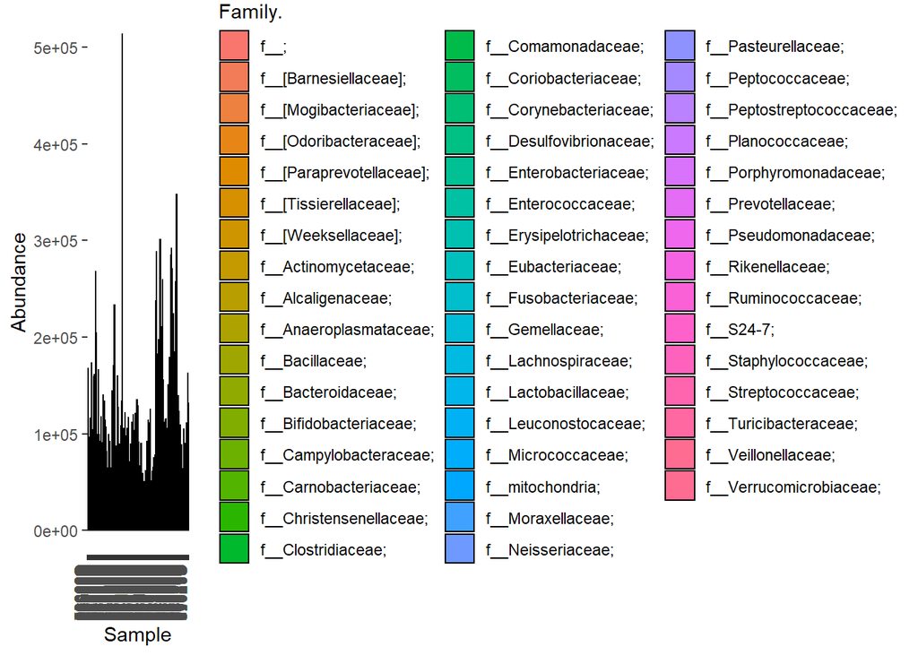

```r
plot_bar(physeq, fill = "Family.")
```

## **Question 3**

### Generate Alpha diversity plots and ordination plots. Examine any observed patterns by delivery mode, gender and disease status.

#### **Step 1**

#### a. Generate a default plot from the plot_richness function.

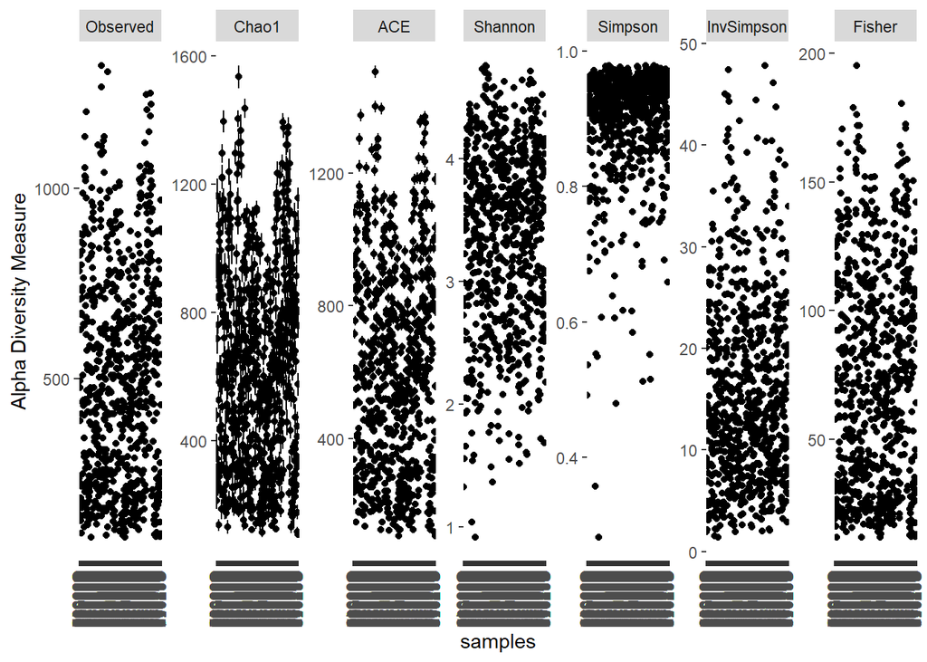

```r
plot_richness(physeq)
```

#### b. Merge the sample data into the phyloseq object, this will help to observe patterns across variables.

```r
Samdata <- column_to_rownames(dataset, var="ï..Sample_ID")
Samdata <- sample_data(Samdata)
```

#### c. view the dataset

```r
#Samdata
```

#### d. Merge the physeq data and the sample data

```r
mergedPhyseq = merge_phyloseq(physeq, Samdata)
mergedPhyseq
```

```
## phyloseq-class experiment-level object
## otu_table()   OTU Table:         [ 2240 taxa and 777 samples ]
## sample_data() Sample Data:       [ 777 samples by 5 sample variables ]
## tax_table()   Taxonomy Table:    [ 2240 taxa by 7 taxonomic ranks ]
```

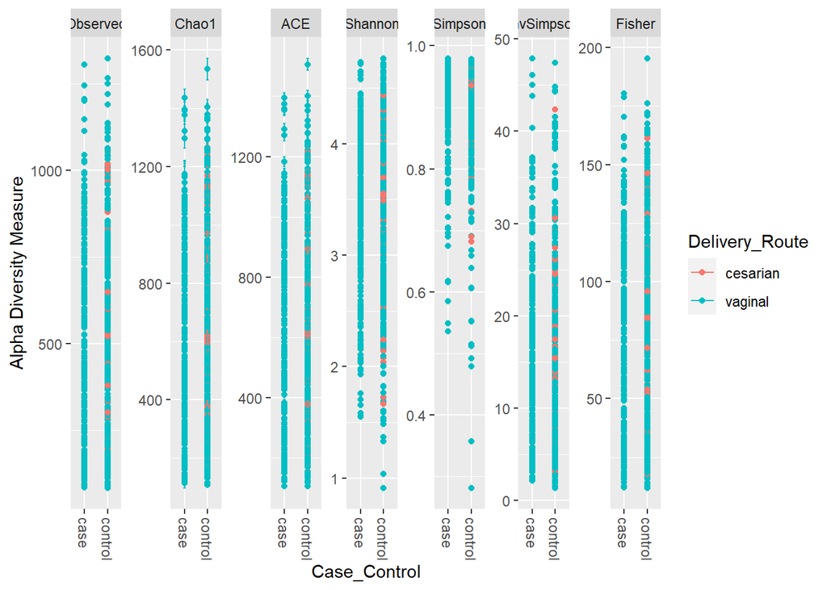

```r
plot_richness(mergedPhyseq, x ="Case_Control", color="Delivery_Route")
```

#### f. Alpha diversity plot of Gender and Case Control.

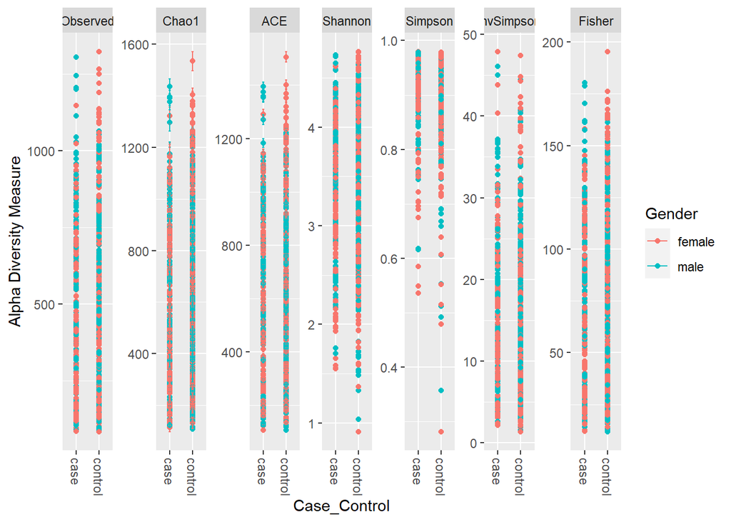

```r
plot_richness(mergedPhyseq, x ="Case_Control", color="Gender")
```

#### g. Alpha diversity plot of Age and Case Control.

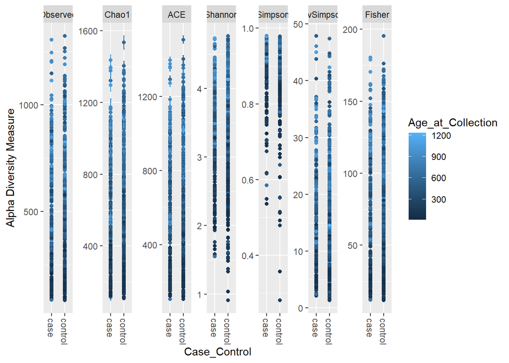

```r
plot_richness(mergedPhyseq, x ="Case_Control", color="Age_at_Collection")
```

## **Question 4**

### Perform differential abundance using DEseq2

### **Step 1: Convert phyloseq object to deseq**

```r
cacos = phyloseq_to_deseq2(mergedPhyseq, ~ Case_Control)
```

### **Step 2: Calculate geometric mean to estimate size factor**

```r
gm_mean = function(x, na.rm=TRUE){
  exp(sum(log(x[x > 0]), na.rm=na.rm) / length(x))
}
geoMeans = apply(counts(cacos), 1, gm_mean)
cacos = estimateSizeFactors(cacos, geoMeans = geoMeans)
cacos = DESeq(cacos, fitType="local")
```

```
## -- replacing outliers and refitting for 1151 genes
## -- DESeq argument 'minReplicatesForReplace' = 7
## -- original counts are preserved in counts(dds)
```

### **Step 3: Conduct the test using the DESeq function**

```r
cacos = DESeq(cacos, test="Wald", fitType="parametric")
```

```
## found already estimated dispersions, replacing these
```

```
## -- replacing outliers and refitting for 1151 genes
## -- DESeq argument 'minReplicatesForReplace' = 7
## -- original counts are preserved in counts(dds)
```

### **Step 4: Investigate the test result table**

```r
res = results(cacos, cooksCutoff = FALSE)
alpha = 0.01
sigtab = res[which(res$padj < alpha), ]
sigtab = cbind(as(sigtab, "data.frame"), as(tax_table(mergedPhyseq)[rownames(sigtab), ], "matrix"))
head(sigtab)
```

```
##            baseMean log2FoldChange     lfcSE      stat       pvalue
## 134726     5.650900       2.131343 0.5677746  3.753854 1.741366e-04
## 193672    91.723631       1.574411 0.2339004  6.731115 1.683680e-11
## 4439360 1081.732052       1.293404 0.2630281  4.917359 8.771937e-07
## 306299     7.927932       1.012606 0.2725292  3.715586 2.027331e-04
## 1142029   25.917987      -1.281229 0.2384803 -5.372474 7.766380e-08
## 4372612   14.952956       1.153463 0.2794945  4.126959 3.675921e-05
##                 padj      Domain.            Phylum.             Class.
## 134726  1.796095e-03 k__Bacteria;     p__Firmicutes;        c__Bacilli;
## 193672  1.215617e-09 k__Bacteria;     p__Firmicutes;     c__Clostridia;
## 4439360 2.083335e-05 k__Bacteria;  p__Bacteroidetes;    c__Bacteroidia;
## 306299  2.032962e-03 k__Bacteria;     p__Firmicutes;     c__Clostridia;
## 1142029 2.761921e-06 k__Bacteria; p__Actinobacteria; c__Actinobacteria;
## 4372612 4.988750e-04 k__Bacteria;  p__Bacteroidetes;    c__Bacteroidia;
##                        Order.                Family.              Genus.
## 134726    o__Lactobacillales;   f__Lactobacillaceae;   g__Lactobacillus;
## 193672      o__Clostridiales;     f__Clostridiaceae;                g__;
## 4439360     o__Bacteroidales;     f__Bacteroidaceae;     g__Bacteroides;
## 306299      o__Clostridiales;    f__Lachnospiraceae;                g__;
## 1142029 o__Bifidobacteriales; f__Bifidobacteriaceae; g__Bifidobacterium;
## 4372612     o__Bacteroidales;     f__Bacteroidaceae;     g__Bacteroides;
##         Species
## 134726      s__
## 193672      s__
## 4439360     s__
## 306299      s__
## 1142029     s__
## 4372612     s__
```

### **Step 5: Visualize the result**

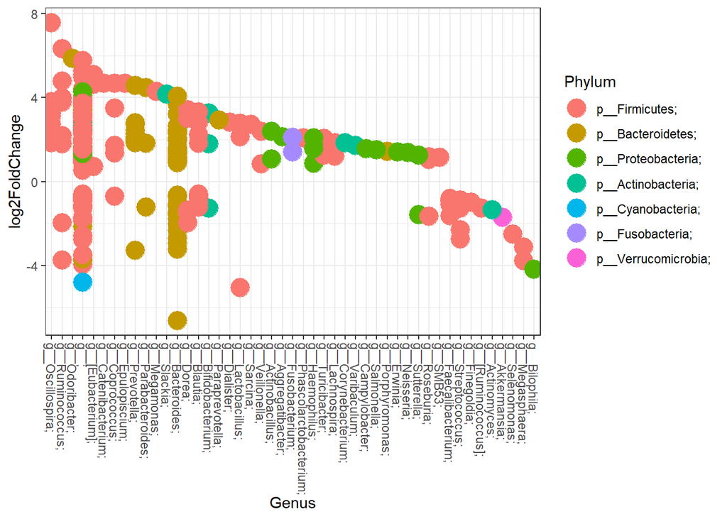

```r
library("ggplot2")
theme_set(theme_bw())
scale_fill_discrete <- function(palname = "Set1", ...) {
    scale_fill_brewer(palette = palname, ...)
}
# Phylum order
x = tapply(sigtab$log2FoldChange, sigtab$Phylum, function(x) max(x))
x = sort(x, TRUE)
sigtab$Phylum = factor(as.character(sigtab$Phylum), levels=names(x))
# Genus order
x = tapply(sigtab$log2FoldChange, sigtab$Genus, function(x) max(x))
x = sort(x, TRUE)
sigtab$Genus = factor(as.character(sigtab$Genus), levels=names(x))
ggplot(sigtab, aes(x=Genus, y=log2FoldChange, color=Phylum)) + geom_point(size=6) +
  theme(axis.text.x = element_text(angle = -90, hjust = 0, vjust=0.5))
```